# Trabajo Fin de Máster

Predicción e interpretación de la pobreza multidimensional en Argentina mediante Machine Learning e Inteligencia Artificial Explicable (2016–2025)

Luis Miguel Herrera Corrales

2026-07-16

# Inteligencia Artificial para comprender la pobreza multidimensional en Argentina

## Objetivo

Construir un sistema de Machine Learning interpretable capaz de identificar los factores estructurales asociados a la pobreza multidimensional en Argentina a través de la metodología Alkire-Foster, incorporando explicabilidad mediante técnicas XAI y evaluando su robustez frente al cambio metodológico introducido por el Censo 2022.

2016–2025

Serie temporal utilizada

6

Regiones EPH

3

Modelos de Machine Learning

XAI

SHAP + Break-Down Plots

# Metodología

Este trabajo propone un enfoque metodológico híbrido: la construcción de un Índice de Pobreza Multidimensional (IPM) bajo la metodología de Alkire-Foster (k = 1/3) utilizando la Encuesta Permanente de Hogares (EPH-INDEC), combinado con algoritmos de Machine Learning y herramientas de Explicabilidad (SHAP-BreakDown) para analizar la heterogeneidad regional.

Dimensiones del IPM Evaluadas

• **Vivienda**: Calidad de los materiales del piso y del techo (carácter deficitario).

• **Saneamiento**: Acceso a agua potable de red y conexión formal a la red de cloacas.

• **Educación**: Asistencia escolar en menores y nivel educativo alcanzado por el jefe de hogar.

### Datos

Microdatos EPH

IPC Regional

Factores de expansión

➡

### Procesamiento

Deflactación

Imputación

SMOTE-NC

MCA

➡

### Modelado

CART

Random Forest

XGBoost

➡

### Validación

Block CV

Split 2016–23

Test 2024

Test externo 2025

➡

### Explicabilidad

SHAP

Break-down

# Principales innovaciones

### Deflactación regional

Los ingresos fueron convertidos a pesos constantes utilizando el IPC específico de cada región del INDEC, evitando el sesgo del promedio nacional en un contexto de alta inflación.

### Validación espacial

Se aplicó **Block Cross Validation**, aislando completamente los conglomerados urbanos entre entrenamiento y validación para evitar *data leakage* geográfico.

### Evaluación temporal

El modelo se entrenó con datos 2016–2023, se evaluó en 2024 y después se evaluó sobre un conjunto externo de 2025 construido bajo el nuevo marco censal, permitiendo medir su resiliencia frente al cambio metodológico.

### Inteligencia Artificial Explicable

# Resultados principales

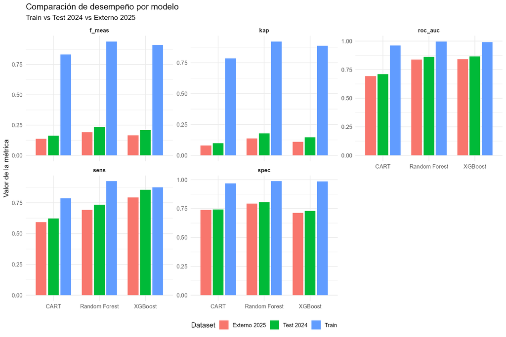

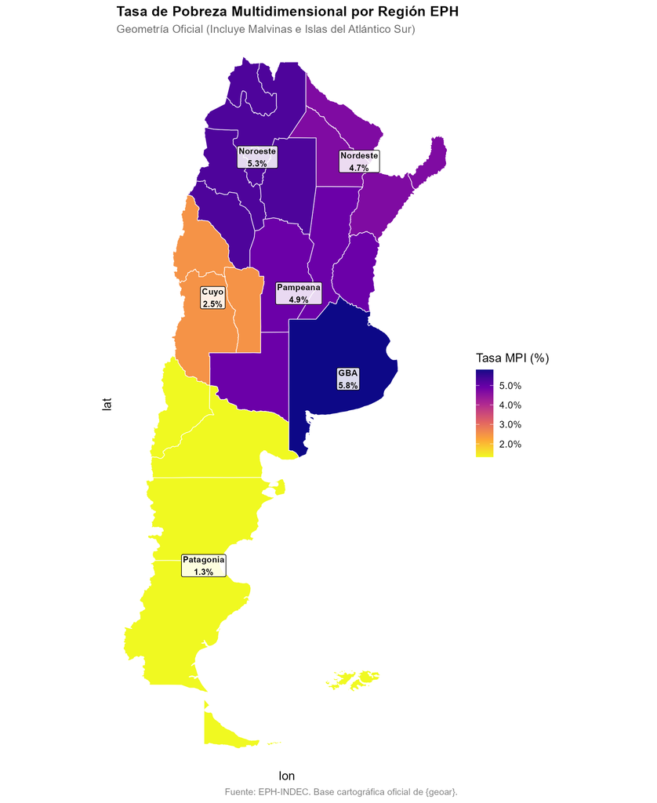

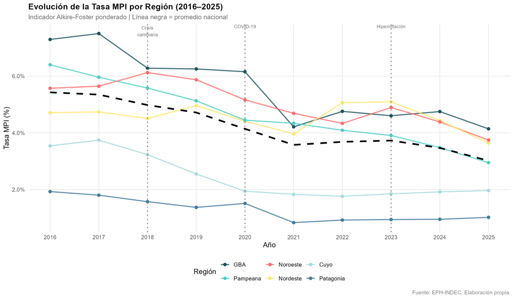

### Hallazgo principal

**XGBoost obtuvo el mejor desempeño predictivo**, manteniendo una capacidad de discriminación elevada incluso tras el cambio censal de 2025. **Random Forest también logró resultados destacables**

# 📈 Resultados del modelo

### 🏆 Comparativa de modelos

| Modelo | AUC Test | AUC 2025 |
| --- | --- | --- |
| 🌳 CART | 0.711 | 0.690 |
| 🌲 Random Forest | 0.863 | 0.838 |
| ⚡ XGBoost | **0.865** | **0.841** |

### 📉 Cambio censal 2025

El cambio metodológico del INDEC produjo una caída muy moderada:

## Δ AUC ≈ 0.024

El modelo mantiene un alto nivel de generalización.

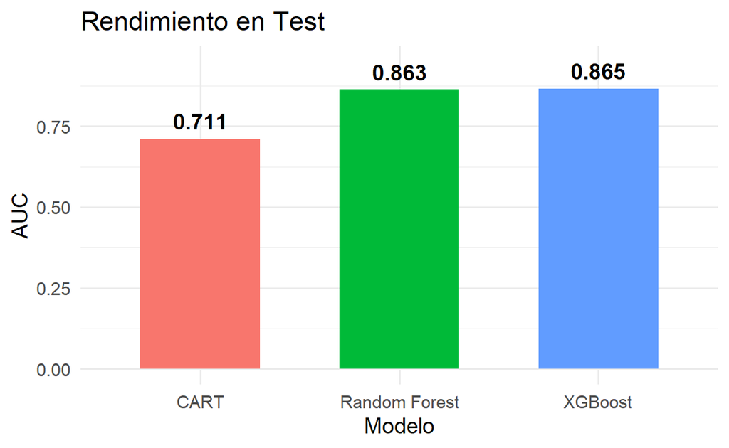

# 🔎 Inteligencia Artificial Explicable (XAI)

### ¿Qué técnicas se aplicaron?

✅ SHAP global

✅ SHAP regional

✅ Break-Down

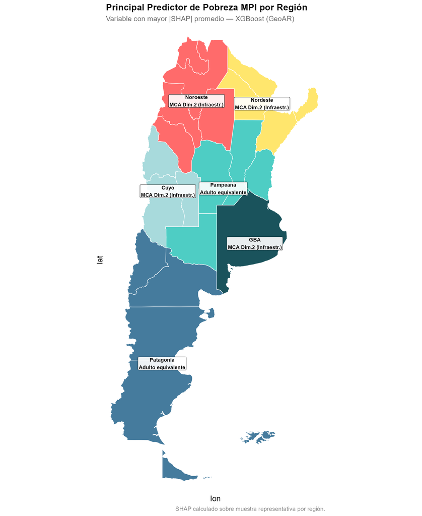

[figure not shown]

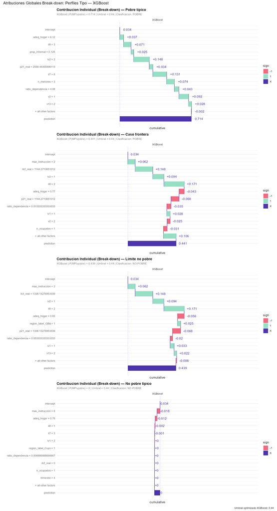

Estas herramientas permiten conocer **por qué** un hogar recibe determinada probabilidad de pobreza.

### Variables más influyentes

🏠 Calidad de vivienda

🚰 Acceso a agua y saneamiento

💰 Ingreso real per cápita

🎓 Educación del hogar

👷 Situación laboral

Las variables cambian de importancia entre regiones, mostrando heterogeneidad territorial.

# 🌎 Aporte para políticas públicas

### El proyecto demuestra que es posible construir modelos explicables para:

✔ focalizar programas sociales

✔ priorizar territorios vulnerables

✔ simular escenarios de política pública

✔ mejorar la asignación de recursos

✔ identificar determinantes regionales de la pobreza

# ⚠ Limitaciones

- La EPH representa únicamente población urbana.
- El IPM captura privaciones estructurales más que shocks coyunturales.
- Existe cierto solapamiento conceptual entre algunos predictores y el indicador objetivo.
- Futuras investigaciones deberían incorporar datos longitudinales y registros administrativos.

# 🚀 Conclusiones

## ✔ XGBoost obtuvo el mejor desempeño.

## ✔ La explicabilidad permitió interpretar las decisiones del modelo.

## ✔ Existen diferencias regionales importantes en los determinantes de la pobreza.

## ✔ El enfoque puede servir como herramienta de apoyo para el diseño y evaluación de políticas sociales.

## **Trabajo Fin de Máster**

### Máster en Ciencias Sociales Computacionales

**Universidad Carlos III de Madrid**

**Luis Miguel Herrera Corrales** *lm.hcor@gmail.com* *https://github.com/lm-hcor* *in/lmhcor/*